# Elons_Tweet_test

## Context

Elon Musk, billionaire and onwer of Tesla, the electric car company, is on trial after investors claimed a 2018 tweet cost them millions of dollars when a deal did not go ahead.  
In the August 7th tweet, Musk wrote that he had "funding secured" to take Tesla private at $420 (£341) per share, and that "investor support is confirmed". The tweet sent shares in Tesla soaring, but weeks later they fell back when Musk said the plan was no longer going ahead, causing a significant backlash for the billionaire.  
At the jury trial in a San Francisco court on January, he stated that "Just because I tweet something does not mean people believe it or will act accordingly".  
Is this really true or is the tycoon underestimating his power to move the financial market?  
Lucky for us, we can do an impact analysis to find that answer.

```python
import yfinance as yf
from causalimpact import CausalImpact
import pandas as pd
import seaborn as sns
import matplotlib.pyplot as plt
```

```python
#Dates
training_start = "2018-06-06" #-2 months
training_end = "2018-08-06" #-1 business day
treatment_start = "2018-08-07" #*tweet date
treatment_end = "2018-08-10" #+3 business days
end_stock = "2018-08-13" #+1 business day
```

#### Loading Data

```python
#Tesla
y = ['TSLA']
y = yf.download(tickers = y,
               start = training_start,
               end = end_stock,
               interval = '1d')
y = y['Adj Close'].rename('y')
y
```

```
[*********************100%***********************]  1 of 1 completed
```

```
Date
2018-06-06    21.299999
2018-06-07    21.072666
2018-06-08    21.177334
2018-06-11    22.139999
2018-06-12    22.851334
2018-06-13    22.985332
2018-06-14    23.848000
2018-06-15    23.878000
2018-06-18    24.722000
2018-06-19    23.503332
2018-06-20    24.148001
2018-06-21    23.167334
2018-06-22    22.242001
2018-06-25    22.200666
2018-06-26    22.799999
2018-06-27    22.966667
2018-06-28    23.328667
2018-06-29    22.863333
2018-07-02    22.337999
2018-07-03    20.724001
2018-07-05    20.610666
2018-07-06    20.593332
2018-07-09    21.233999
2018-07-10    21.497999
2018-07-11    21.264000
2018-07-12    21.114000
2018-07-13    21.257999
2018-07-16    20.673332
2018-07-17    21.512667
2018-07-18    21.590000
2018-07-19    21.348667
2018-07-20    20.905333
2018-07-23    20.213333
2018-07-24    19.828667
2018-07-25    20.582666
2018-07-26    20.443333
2018-07-27    19.812000
2018-07-30    19.344667
2018-07-31    19.875999
2018-08-01    20.056000
2018-08-02    23.302668
2018-08-03    23.211332
2018-08-06    22.799334
2018-08-07    25.304667
2018-08-08    24.689333
2018-08-09    23.496668
2018-08-10    23.699333
Name: y, dtype: float64
```

#### Assumptions

- Parallel Trends Assumption: The treatment and Control Groups are assumed to have the same evolution for the KPI
- Confounding Policy Change: There must be only one policy or initiative that differentiates the treatment from control groups.

How to Strengthen the assumptions:

- Use more control groups. The more comparable groups you havem the more you reinforce the causality.
- Extend the pre period. The more data you have, the more you have to see whether the groups are comparable and would develop similarly or not as a result.
- Keep post-period to the bare minimum. This minimizes the possibility of othr events affecting the results.

```python
stocks = ['GM', 'F', 'TM', 'VWAGY', 'MBGYY', 'BMWYY', 'RACE', 'HMC', 'VLVLY', 'STLA', 'GWLLY']

X = yf.download(tickers = stocks,
               start = training_start,
               end = end_stock,
               interval = '1d')
```

```
[*********************100%***********************]  11 of 11 completed
```

```python
#Getting the adjusted close
X = X.iloc[:, :len(stocks)]
X.columns = X.columns.droplevel()
```

```python
#Ignore timezone
X.index = X.index.tz_localize(None)
```

```python
#Combine data
df = pd.concat([y,X], axis = 1).dropna()
```

```python
df.head()
```

| Date | y | BMWYY | F | GM | GWLLY | HMC | MBGYY | RACE | STLA | TM | VLVLY | VWAGY |
| --- | --- | --- | --- | --- | --- | --- | --- | --- | --- | --- | --- | --- |
| 2018-06-06 | 21.299999 | 28.131603 | 9.691560 | 40.237675 | 8.511659 | 28.480118 | 15.193603 | 135.666534 | 14.376102 | 136.169998 | 13.556982 | 15.649733 |
| 2018-06-07 | 21.072666 | 27.787136 | 9.740140 | 40.662685 | 8.554864 | 28.409384 | 15.094515 | 132.738403 | 14.525499 | 136.449997 | 13.207892 | 15.527372 |
| 2018-06-08 | 21.177334 | 27.614901 | 9.796817 | 40.884430 | 8.554864 | 28.435909 | 15.061485 | 132.660568 | 14.362523 | 136.210007 | 13.096643 | 15.455997 |
| 2018-06-11 | 22.139999 | 27.557489 | 9.740140 | 41.438793 | 8.390680 | 28.886852 | 14.855049 | 135.296860 | 14.457594 | 137.149994 | 13.296124 | 15.294889 |
| 2018-06-12 | 22.851334 | 27.442667 | 9.804912 | 40.819763 | 8.390680 | 28.435909 | 15.102774 | 136.814407 | 14.335359 | 134.550003 | 13.193315 | 15.270419 |

#### Data Analysis

- Prepare a dataframe with only training data

```python
df_training = df[df.index <=  training_end]
df_training.tail(1)
```

| Date | y | BMWYY | F | GM | GWLLY | HMC | MBGYY | RACE | STLA | TM | VLVLY | VWAGY |
| --- | --- | --- | --- | --- | --- | --- | --- | --- | --- | --- | --- | --- |
| 2018-08-06 | 22.799334 | 26.44207 | 8.234994 | 34.740219 | 5.642754 | 26.782454 | 13.880677 | 120.617332 | 11.422108 | 128.449997 | 12.912508 | 13.516603 |

- Testing for stationary data

```python
from statsmodels.tsa.stattools import adfuller
```

```python
def dickey_fuller(df, col):
    test = adfuller(x = df[col])[1]
    if test < 0.05:
        print("the time series is stationary")
    else:
        print("the time series is not stationary")
```

```python
dickey_fuller(df_training, 'y')
```

```
the time series is not stationary
```

```python
#Differencing for stationary transformation
differencing = df_training.pct_change().dropna()
differencing.head(2)
```

| Date | y | BMWYY | F | GM | GWLLY | HMC | MBGYY | RACE | STLA | TM | VLVLY | VWAGY |
| --- | --- | --- | --- | --- | --- | --- | --- | --- | --- | --- | --- | --- |
| 2018-06-07 | -0.010673 | -0.012245 | 0.005013 | 0.010563 | 0.005076 | -0.002484 | -0.006522 | -0.021583 | 0.010392 | 0.002056 | -0.025750 | -0.007819 |
| 2018-06-08 | 0.004967 | -0.006198 | 0.005819 | 0.005453 | 0.000000 | 0.000934 | -0.002188 | -0.000586 | -0.011220 | -0.001759 | -0.008423 | -0.004597 |

```python
dickey_fuller(differencing, 'y')
```

```
the time series is stationary
```

##### Correlation Matrix

- we do the correlation matrix in data tha has similar statistical properties and not in data that may just correlate due to the trend

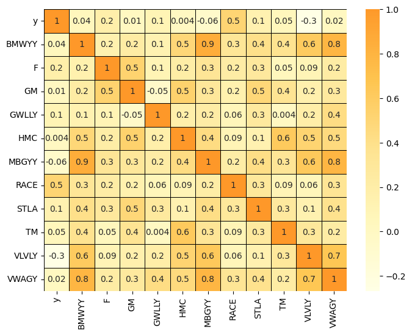

```python
plt.figure(figsize = (8,6)) #smaller
sns.heatmap(differencing.corr(),
           annot = True,
           fmt = '.1g',
           cmap = 'YlOrBr',
           center = True,
           linecolor = 'black',
           linewidth = 0.5)
#annot: include the values
#fmt: 1 digit
```

the only ones that make sense for us to keep - given the parallel trends assumption - are F (Ford Motor), GWLLY (Great Wall Motor), RACE (Ferrari) and STLA (Stellantis)

```python
df_final = df[['y', 'F', 'GWLLY', 'RACE', 'STLA']].copy()
```

```python
#Pre and post period
pre_period = [training_start, training_end]
post_period = [treatment_start, treatment_end]
```

#### Google Causal Impact

[output not shown]

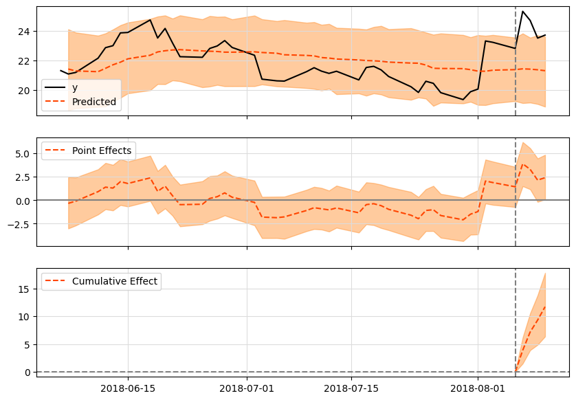

```python
impact = CausalImpact(data = df_final,
                     pre_period = pre_period,
                     post_period = post_period)
impact.plot()
```

```python
print(impact.summary())
```

```
Posterior Inference {Causal Impact}
                          Average            Cumulative
Actual                    24.3               97.19
Prediction (s.d.)         21.37 (0.68)       85.47 (2.72)
95% CI                    [19.96, 22.62]     [79.85, 90.5]

Absolute effect (s.d.)    2.93 (0.68)        11.72 (2.72)
95% CI                    [1.67, 4.34]       [6.69, 17.34]

Relative effect (s.d.)    13.71% (3.18%)     13.71% (3.18%)
95% CI                    [7.83%, 20.29%]    [7.83%, 20.29%]

Posterior tail-area probability p: 0.0
Posterior prob. of a causal effect: 100.0%

For more details run the command: print(impact.summary('report'))
```

```python
print(impact.summary('report'))
```

```
Analysis report {CausalImpact}


During the post-intervention period, the response variable had
an average value of approx. 24.3. By contrast, in the absence of an
intervention, we would have expected an average response of 21.37.
The 95% interval of this counterfactual prediction is [19.96, 22.62].
Subtracting this prediction from the observed response yields
an estimate of the causal effect the intervention had on the
response variable. This effect is 2.93 with a 95% interval of
[1.67, 4.34]. For a discussion of the significance of this effect,
see below.


Summing up the individual data points during the post-intervention
period (which can only sometimes be meaningfully interpreted), the
response variable had an overall value of 97.19.
By contrast, had the intervention not taken place, we would have expected
a sum of 85.47. The 95% interval of this prediction is [79.85, 90.5].


The above results are given in terms of absolute numbers. In relative
terms, the response variable showed an increase of +13.71%. The 95%
interval of this percentage is [7.83%, 20.29%].


This means that the positive effect observed during the intervention
period is statistically significant and unlikely to be due to random
fluctuations. It should be noted, however, that the question of whether
this increase also bears substantive significance can only be answered
by comparing the absolute effect (2.93) to the original goal
of the underlying intervention.


The probability of obtaining this effect by chance is very small
(Bayesian one-sided tail-area probability p = 0.0).
This means the causal effect can be considered statistically
significant.
```

## Conclusion

As we can see, the tweet did result in a move in Tesla stock, with a statistically significant impact.  
Citing Loyola law professor Jessica Levinson, in an interview to [The Guardian](https://www.theguardian.com/technology/2023/jan/28/tesla-trial-elon-musk-what-you-need-to-know-explainer) on the subject, "(...) that quick tweet did have a very real impact on people”.